# ME613 - Análise de Regressão

## Modelo de Regressão Polinomial

## Introdução

Podemos considerar funções polinomiais como um caso particular do modelo de regressão linear já visto.

## Modelo com um preditor - segunda ordem

\[Y=\beta_0+\beta_1X_*+\beta_2X_*^2+\varepsilon\]

em que \(X_*=X-\bar{X}\).

Função de resposta quadrática.

\(\beta_0\): valor esperado de \(Y\) quando \(X_*\) é zero, isto é, \(X=\bar{X}\).

\(\beta_1\): coeficiente de efeito linear.

\(\beta_2\): coeficiente de efeito quadrático.

## Exemplo

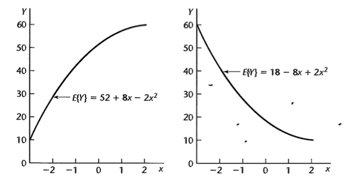

## Modelo com um preditor - terceira ordem

\[Y=\beta_0+\beta_1X_*+\beta_2X_*^2+\beta_3X_*^3+\varepsilon\]

em que \(X_*=X-\bar{X}\).

Exemplos:

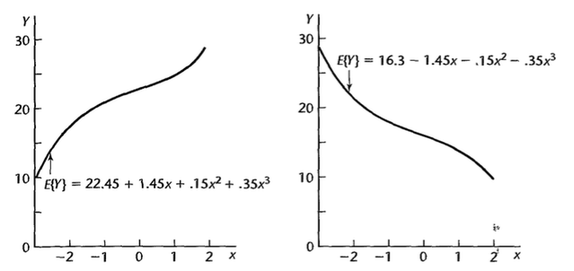

## Modelo com dois preditores - segunda ordem

\[Y=\beta_0+\beta_1X_{1*}+\beta_2X_{1*}^2+\beta_3X_{2*}+\beta_4X_{2*}^2+\beta_5X_{1*}X_{2*}+\varepsilon\]

em que \(X_{1*}=X_1-\bar{X}_1\) e \(X_{2*}=X_2-\bar{X}_2\).

## Exemplo

\[E(Y)=1740-4X_{1*}^2-3X_{2*}^2-3X_{1*}X_{2*}\]

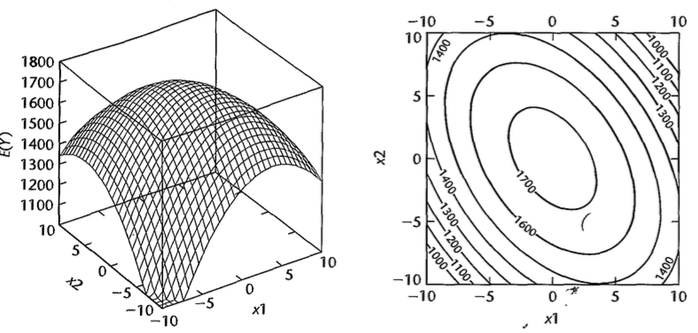

## Método hierárquico de ajuste de modelo

Pode-se começar com um modelo de segunda ou terceira ordem e ir testando se os coeficientes de ordem maiores são significativos.

Por exemplo:

\[Y=\beta_0+\beta_1X_{*}+\beta_2X_*^2+\beta_3X_*^3+\varepsilon\]

Para testar se \(\beta_3=0\) podemos utilizar \(SQReg(X_*^3\mid X_*,X_*^2)\). Se quisermos testar se \(\beta_2=\beta_3=0\): \(SQReg(X_*^2,X_*^3\mid X_*)=SQReg(X_*^2\mid X_*)+SQReg(X_*^3\mid X_*, X_*^2)\)

Se um termo de ordem mais alta é mantido no modelo, os de ordem mais baixa devem obrigatoriamente ser mantidos também.

## Exemplo

\(Y\): número de ciclos

\(X_1\): carga, \(X_{1*}=(X_1-\bar{X}_1)/0.4\).

\(X_2\): temperatura, \(X_{2*}=(X_2-\bar{X}_2)/10\).

```r
dados <- read.table("./dados/CH08TA01.txt")
names(dados) <- c("Y","X1","X2")
dados$x1 <- (dados$X1-mean(dados$X1))/0.4
dados$x2 <- (dados$X2-mean(dados$X2))/10
```

```
##      Y  X1 X2 x1 x2
## 1  150 0.6 10 -1 -1
## 2   86 1.0 10  0 -1
## 3   49 1.4 10  1 -1
## 4  288 0.6 20 -1  0
## 5  157 1.0 20  0  0
## 6  131 1.0 20  0  0
## 7  184 1.0 20  0  0
## 8  109 1.4 20  1  0
## 9  279 0.6 30 -1  1
## 10 235 1.0 30  0  1
## 11 224 1.4 30  1  1
```

## Exemplo

Correlação entre \(X_1\) e \(X_1^2\): 0.99.

Correlação entre \(X_{1*}\) e \(X_{1*}^2\): 0.

Correlação entre \(X_2\) e \(X_2^2\): 0.99.

Correlação entre \(X_{2*}\) e \(X_{2*}^2\): 0.

## Exemplo

\[Y=\beta_0+\beta_1X_{1*}+\beta_2X_{2*}+\beta_3X_{1*}^2+\beta_4X_{2*}^2+\beta_5X_{1*}X_{2*}+\varepsilon\]

```r
modelo <- lm(Y ~ x1 + x2 + I(x1^2) + I(x2^2) + I(x1*x2),data=dados)
summary(modelo)$coef
```

```
##              Estimate Std. Error    t value    Pr(>|t|)
## (Intercept) 162.84211   16.60761  9.8052730 0.000187839
## x1          -55.83333   13.21670 -4.2244519 0.008292287
## x2           75.50000   13.21670  5.7124677 0.002297266
## I(x1^2)      27.39474   20.34008  1.3468353 0.235856323
## I(x2^2)     -10.60526   20.34008 -0.5213973 0.624352247
## I(x1 * x2)   11.50000   16.18709  0.7104426 0.509183728
```

## Exemplo

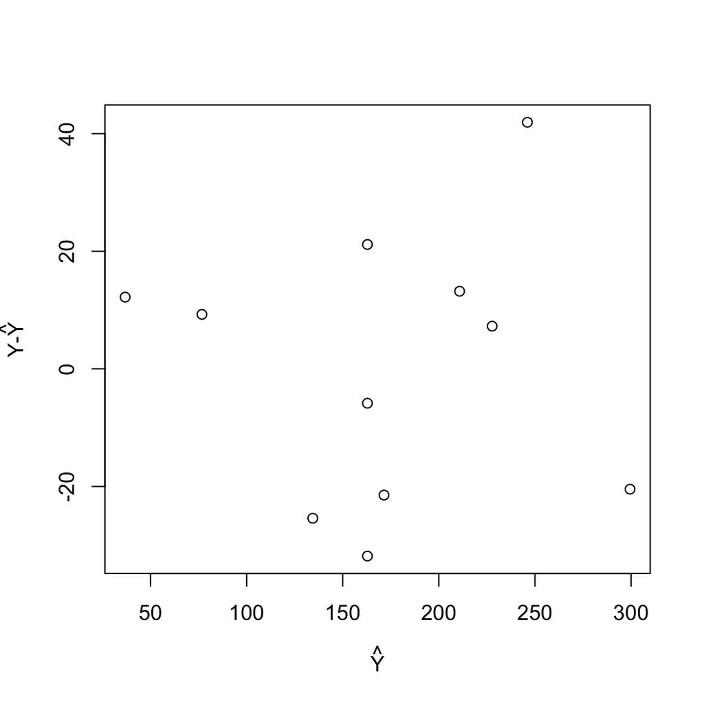

## Exemplo

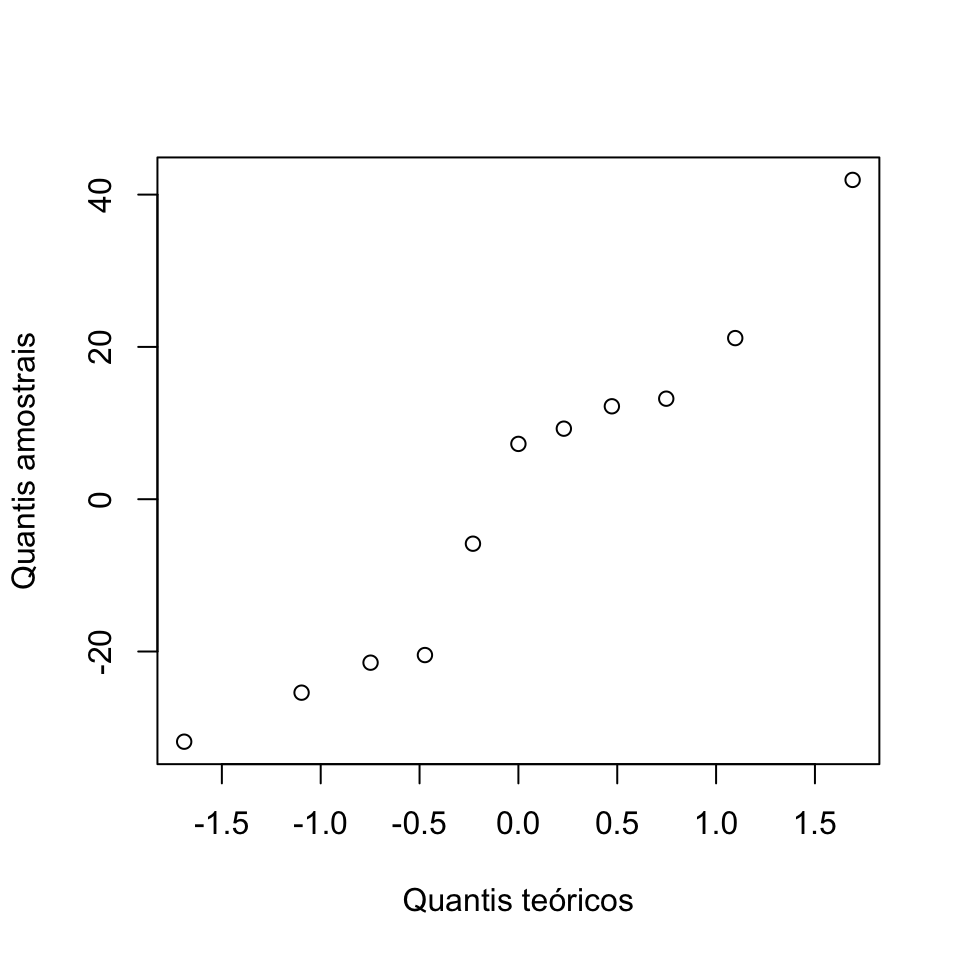

## Exemplo

```r
library(alr3)
pureErrorAnova(modelo)
```

```
## Analysis of Variance Table
##
## Response: Y
##              Df Sum Sq Mean Sq F value  Pr(>F)
## x1            1  18704   18704 26.6315 0.03556 *
## x2            1  34202   34202 48.6970 0.01992 *
## I(x1^2)       1   1646    1646  2.3436 0.26546
## I(x2^2)       1    285     285  0.4057 0.58935
## I(x1 * x2)    1    529     529  0.7532 0.47696
## Residuals     5   5240    1048
##  Lack of fit  3   3836    1279  1.8205 0.37378
##  Pure Error   2   1405     702
## ---
## Signif. codes:  0 '***' 0.001 '**' 0.01 '*' 0.05 '.' 0.1 ' ' 1
```

Não rejeitamos \(H_0\), isto é, não encontramos evidências para rejeitar que o modelo de segunda ordem é um bom ajuste

## Exemplo

Será que um modelo de primeira ordem já seria suficiente?

\[Y=\beta_0+\beta_1X_{1*}+\beta_2X_{2*}+\beta_3X_{1*}^2+\beta_4X_{2*}^2+\beta_5X_{1*}X_{2*}+\varepsilon\]

\(H_0\): \(\beta_3=\beta_4=\beta_5=0\).

\(H_a\): pelo menos um entre \(\beta_3, \beta_4\) e \(\beta_5\) é diferente de zero.

```
## Analysis of Variance Table
##
## Response: Y
##            Df Sum Sq Mean Sq F value   Pr(>F)
## x1          1  18704   18704 17.8460 0.008292 **
## x2          1  34202   34202 32.6323 0.002297 **
## I(x1^2)     1   1646    1646  1.5704 0.265552
## I(x2^2)     1    285     285  0.2719 0.624352
## I(x1 * x2)  1    529     529  0.5047 0.509184
## Residuals   5   5240    1048
## ---
## Signif. codes:  0 '***' 0.001 '**' 0.01 '*' 0.05 '.' 0.1 ' ' 1
```

## Exemplo

- \(H_0\): \(\beta_q=\beta_{q+1}=\ldots=\beta_{p-1}=0\).
- \(H_1\): pelo menos um \(\beta_q,\ldots,\beta_{p-1}\) não é zero.

(por conveniência, a notação assume que os últimos \(p-q\) coeficientes do modelo serão testados)

Estatística do teste:

\[\begin{eqnarray} F^*&=&\frac{SQReg(X_q,\ldots, X_{p-1}\mid X_1,\ldots,X_{q-1})}{p-q}\div\frac{SQE(X_1,\ldots,X_{p-1})}{n-p}\\ &\overset{\mbox{sob $H_0$}}{\sim}&F_{p-q,n-p} \end{eqnarray}\]

## Exemplo

\(p=6\)

\(n = 11\)

\(q=3\)

\[F^*=\frac{SQReg(X_{1*}^2,X_{2*}^2,X_{1*}X_{2*}\mid X_{1*},X_{2*})/3}{SQE(X_{1*},X_{2*},X_{1*}^2,X_{2*}^2,X_{1*}X_{2*})/5}\overset{\mbox{sob $H_0$}}{\sim}F_{3,5}\]

\[\begin{eqnarray} SQReg(X_{1*}^2,X_{2*}^2,X_{1*}X_{2*}\mid X_{1*},X_{2*}) &=& SQReg(X_{1*}^2\mid X_{1*},X_{2*})\\ &+& SQReg(X_{2*}^2\mid X_{1*},X_{2*},X_{1*}^2)\\ &+&SQReg(X_{1*}X_{2*}\mid X_{1*},X_{2*},X_{1*}^2,X_{2*}^2)\\ &=&1646 + 284.9 +529\\ &=& 2459.9 \end{eqnarray}\]

\[F_{obs}=\frac{2459.9/3}{1048.1}=0.7823363\]

Comparando com \(F(0.95;3,5)=5.41\), não encontramos evidências contra a hipótese nula.

## Exemplo

```r
modeloreduz <- lm(Y ~ x1 + x2,data=dados)
anova(modeloreduz,modelo)
```

```
## Analysis of Variance Table
##
## Model 1: Y ~ x1 + x2
## Model 2: Y ~ x1 + x2 + I(x1^2) + I(x2^2) + I(x1 * x2)
##   Res.Df    RSS Df Sum of Sq      F Pr(>F)
## 1      8 7700.3
## 2      5 5240.4  3    2459.9 0.7823 0.5527
```

## Exemplo

Modelo de primeira ordem:

\[Y=\beta_0+\beta_1X_{1*}+\beta_2X_{2*}+\varepsilon\]

```r
modelo1 <- lm(Y ~ x1 + x2,data=dados)
summary(modelo1)$coef
```

```
##              Estimate Std. Error   t value     Pr(>|t|)
## (Intercept) 172.00000   9.354346 18.387175 7.880002e-08
## x1          -55.83333  12.665844 -4.408181 2.261894e-03
## x2           75.50000  12.665844  5.960913 3.378234e-04
```

## Exemplo

Modelo de primeira ordem (variáveis nas escalas originais):

\[Y=\beta_0+\beta_1X_{1}+\beta_2X_{2}+\varepsilon\]

```r
modelo1 <- lm(Y ~ X1 + X2,data=dados)
summary(modelo1)$coef
```

```
##              Estimate Std. Error   t value     Pr(>|t|)
## (Intercept)  160.5833  41.615451  3.858743 0.0048174887
## X1          -139.5833  31.664611 -4.408181 0.0022618941
## X2             7.5500   1.266584  5.960913 0.0003378234
```

## Exemplo

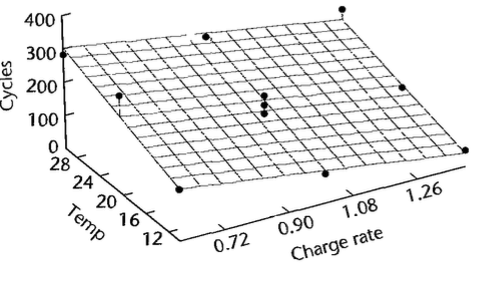

## Modelo de Regressão com Interação

## Efeitos de interação

Um modelo de regressão com \(p-1\) variáveis preditoras com efeitos aditivos tem função de regressão da forma:

\[E(Y)=f_1(X_1)+f_2(X_2)+\ldots+f_{p-1}(X_{p-1})\]

em que \(f_1,f_2,\ldots,f_{p-1}\) podem ser quaisquer funções.

Por exemplo:

\[E(Y)=\underbrace{\beta_0+\beta_1X_1+\beta_2X_1^2}_{f_1(X_1)}+\underbrace{\beta_3X_2}_{f_2(X_2)}\]

O efeito de \(X_1\) e \(X_2\) em \(Y\) é **aditivo**.

## Efeitos de interação

Já no exemplo a seguir, o efeito não é aditivo, há efeito de interação:

\[E(Y)=\beta_0+\beta_1X_1+\beta_2X_1^2+\beta_3X_2+\beta_3X_1X_2\]

Outro exemplo:

\[E(Y)=\beta_0+\beta_1X_1+\beta_2X_2+\beta_3X_3+\beta_4X_1X_2+\beta_5X_1X_3\]

O efeito de uma variável sobre \(Y\) irá depender do nível da variável com a qual ela interage.

## Interpretação: interação e efeitos lineares

\[Y=\beta_0+\beta_1X_1+\beta_2X_2+\beta_3X_1X_2+\varepsilon\]

Suponha que \(X_1=a\):

\[E(Y)=\beta_0+\beta_1a+\beta_2X_2+\beta_3aX_2\]

Suponha que \(X_1=a+1\):

\[E(Y)=\beta_0+\beta_1(a+1)+\beta_2X_2+\beta_3(a+1)X_2\]

Diferença no valor esperado de \(Y\) quando aumentamos \(X_1\) em 1 unidade:

\[\beta_0+\beta_1(a+1)+\beta_2X_2+\beta_3(a+1)X_2 - (\beta_0+\beta_1a+\beta_2X_2+\beta_3aX_2)\]

\[=\beta_1+\beta_3X_2\]

## Interpretação: interação e efeitos lineares

\[Y=\beta_0+\beta_1X_1+\beta_2X_2+\beta_3X_1X_2+\varepsilon\]

Suponha que \(X_2=a\):

\[E(Y)=\beta_0+\beta_1X_1+\beta_2a+\beta_3X_1a\]

Suponha que \(X_2=a+1\):

\[E(Y)=\beta_0+\beta_1X_1+\beta_2(a+1)+\beta_3X_1(a+1)\]

Diferença no valor esperado de \(Y\) quando aumentamos \(X_2\) em 1 unidade:

\[\beta_0+\beta_1X_1+\beta_2(a+1)+\beta_3X_1(a+1) - (\beta_0+\beta_1X_1+\beta_2a+\beta_3X_1a)\]

\[=\beta_2+\beta_3X_1\]

## Interpretação: interação e efeitos lineares

\[Y=\beta_0+\beta_1X_1+\beta_2X_2+\beta_3X_1X_2+\varepsilon\]

Diferença no valor esperado de \(Y\) quando aumentamos \(X_1\) em 1 unidade:

\[\frac{\partial E(Y)}{\partial X_1}=\beta_1+\beta_3X_2\]

Diferença no valor esperado de \(Y\) quando aumentamos \(X_2\) em 1 unidade:

\[\frac{\partial E(Y)}{\partial X_2}=\beta_2+\beta_3X_1\]

## Interpretação: interação e efeitos lineares

Modelo aditivo:

\[E(Y)=10+2X_1+5X_2\]

\(\beta_1\): mudança no valor esperado de \(Y\) quando \(X_1\) aumenta em 1 unidade, mantendo \(X_2\) constante.

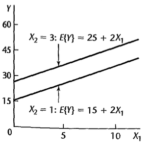

Mantendo \(X_2\) constante: não importa se \(X_2=1\) ou \(X_2=3\) o efeito é sempre \(\beta_1\) no valor esperado quando \(X_1\) aumenta em 1 unidade (retas paralelas).

## Interpretação: interação e efeitos lineares

Modelo com interação:

\[E(Y)=10+2X_1+5X_2 +0.5X_1X_2\]

Se \(X_2=1\):

\[E(Y)=10+2X_1+5\times1 +0.5X_1\times 1=15+2.5X_1\]

Se \(X_2=3\):

\[E(Y)=10+2X_1+5\times3 +0.5X_1\times 3=25+3.5X_1\]

## Interpretação: interação e efeitos lineares

Para avaliarmos o efeito de 1 unidade de aumento em \(X_1\), devemos considerar o valor de \(X_2\) (retas não paralelas).

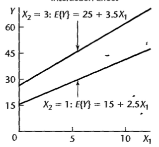

## Interpretação: interação e efeitos curvilinear

Exemplo:

\[E(Y)=65+3X_1+4X_2-10X_1^2-15X_2^2+35X_1X_2\]

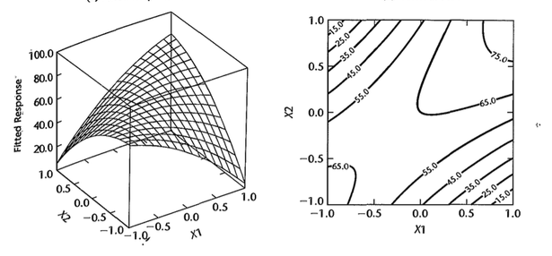

## Interpretação: interação e efeitos curvilinear

Se \(X_1=1\):

\[E(Y)=65+3\times 1+4X_2-10\times(1^2)-15X_2^2+35\times 1\times X_2\]

\[E(Y)=58+39X_2-15X_2^2\]

Se \(X_1=-1\):

\[E(Y)=65+3\times (-1)+4X_2-10\times(-1^2)-15X_2^2+35\times (-1)\times X_2\]

\[E(Y)=52-31X_2-15X_2^2\]

## Interpretação: interação e efeitos curvilinear

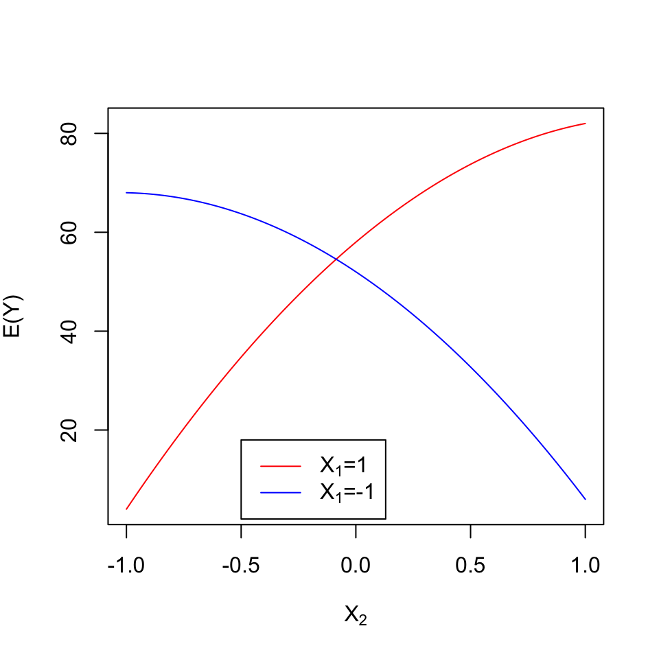

## Exemplo

\(X_1\): tríceps, \(X_{1*}=X_1-\bar{X}_1\).

\(X_2\): coxa, \(X_{2*}=X_2-\bar{X}_2\).

\(X_3\): antebraço, \(X_{3*}=X_1-\bar{X}_3\).

\(Y\): gordura corporal

```
##      X1   X2   X3    Y      x1    x2    x3
## 1  19.5 43.1 29.1 11.9  -5.805 -8.07  1.48
## 2  24.7 49.8 28.2 22.8  -0.605 -1.37  0.58
## 3  30.7 51.9 37.0 18.7   5.395  0.73  9.38
## 4  29.8 54.3 31.1 20.1   4.495  3.13  3.48
## 5  19.1 42.2 30.9 12.9  -6.205 -8.97  3.28
## 6  25.6 53.9 23.7 21.7   0.295  2.73 -3.92
## 7  31.4 58.5 27.6 27.1   6.095  7.33 -0.02
## 8  27.9 52.1 30.6 25.4   2.595  0.93  2.98
## 9  22.1 49.9 23.2 21.3  -3.205 -1.27 -4.42
## 10 25.5 53.5 24.8 19.3   0.195  2.33 -2.82
## 11 31.1 56.6 30.0 25.4   5.795  5.43  2.38
## 12 30.4 56.7 28.3 27.2   5.095  5.53  0.68
## 13 18.7 46.5 23.0 11.7  -6.605 -4.67 -4.62
## 14 19.7 44.2 28.6 17.8  -5.605 -6.97  0.98
## 15 14.6 42.7 21.3 12.8 -10.705 -8.47 -6.32
## 16 29.5 54.4 30.1 23.9   4.195  3.23  2.48
## 17 27.7 55.3 25.7 22.6   2.395  4.13 -1.92
## 18 30.2 58.6 24.6 25.4   4.895  7.43 -3.02
## 19 22.7 48.2 27.1 14.8  -2.605 -2.97 -0.52
## 20 25.2 51.0 27.5 21.1  -0.105 -0.17 -0.12
```

## Exemplo

\[E(Y)=\beta_0+\beta_1X_{1*}+\beta_2X_{2*}+\beta_3X_{3*}+\beta_4X_{1*}X_{2*}+\beta_5X_{1*}X_{3*}+\beta_6X_{2*}X_{3*}+\varepsilon\]

```r
modelo <- lm(Y ~ x1 + x2 + x3 + I(x1*x2) + I(x1*x3) + I(x2*x3),data=dat)
summary(modelo)$coef
```

```
##                 Estimate Std. Error    t value     Pr(>|t|)
## (Intercept) 20.526893531 1.07362646 19.1192136 6.699796e-11
## x1           3.437808068 3.57866572  0.9606396 3.542612e-01
## x2          -2.094717339 3.03676957 -0.6897848 5.024579e-01
## x3          -1.616337237 1.90721068 -0.8474875 4.120550e-01
## I(x1 * x2)   0.008875562 0.03085046  0.2876963 7.781144e-01
## I(x1 * x3)  -0.084790836 0.07341774 -1.1549093 2.689155e-01
## I(x2 * x3)   0.090415385 0.09200130  0.9827621 3.436619e-01
```

## Exemplo

```r
anova(modelo)
```

```
## Analysis of Variance Table
##
## Response: Y
##            Df Sum Sq Mean Sq F value    Pr(>F)
## x1          1 352.27  352.27 52.2238 6.682e-06 ***
## x2          1  33.17   33.17  4.9173   0.04503 *
## x3          1  11.55   11.55  1.7117   0.21343
## I(x1 * x2)  1   1.50    1.50  0.2217   0.64552
## I(x1 * x3)  1   2.70    2.70  0.4009   0.53760
## I(x2 * x3)  1   6.51    6.51  0.9658   0.34366
## Residuals  13  87.69    6.75
## ---
## Signif. codes:  0 '***' 0.001 '**' 0.01 '*' 0.05 '.' 0.1 ' ' 1
```

## Exemplo

\(H_0\): \(\beta_4=\beta_5=\beta_6=0\)

\(H_1\): pelo menos um dentre \(\beta_4,\beta_5,\beta_6\) é diferente de 0.

\(p=7\)

\(n = 20\)

\(q=4\)

\[F^*=\frac{SQReg(X_{1*}X_{2*},X_{1*}X_{3*},X_{2*}X_{3*}\mid X_{1*},X_{2*},X_{3*})/3}{SQE(X_{1*},X_{2*},X_{3*},X_{1*}X_{2*},X_{1*}X_{3*},X_{2*}X_{3*})/13}\overset{\mbox{sob $H_0$}}{\sim}F_{3,13}\]

## Exemplo

\[\begin{eqnarray} SQReg(X_{1*}X_{2*},X_{1*}X_{3*},X_{2*}X_{3*}\mid X_{1*},X_{2*},X_{3*}) &=& SQReg(X_{1*}X_{2*}\mid X_{1*},X_{2*},X_{3*})\\ &+& SQReg(X_{1*}X_{3*}\mid X_{1*},X_{2*},X_{3*},X_{1*}X_{2*})\\ &+&SQReg(X_{2*}X_{3*}\mid X_{1*},X_{2*},X_{3*},X_{1*}X_{2*},X_{1*}X_{3*})\\ &=&1.5 + 2.7 +6.514836\\ &=& 10.714836 \end{eqnarray}\]

\[F_{obs}=\frac{10.714836/3}{6.7}=0.5330764\]

Comparando com \(F(0.95;3,13)=3.41\), não encontramos evidências contra a hipótese nula.

## Exemplo

```r
modeloreduz <- lm(Y ~ x1 + x2 + x3,data=dat)
anova(modeloreduz,modelo)
```

```
## Analysis of Variance Table
##
## Model 1: Y ~ x1 + x2 + x3
## Model 2: Y ~ x1 + x2 + x3 + I(x1 * x2) + I(x1 * x3) + I(x2 * x3)
##   Res.Df    RSS Df Sum of Sq      F Pr(>F)
## 1     16 98.405
## 2     13 87.690  3    10.715 0.5295 0.6699
```

## Preditores Qualitativos

## Exemplo: Seguros

\(Y\) = meses até a implementação

\(X_1\) = tamanho da firma (em milhões de dólares)

\[\begin{eqnarray} X_2 = \begin{cases} 1, & \mbox{se a firma tem açoes na bolsa} \\ 0, & \mbox{caso contrário} \end{cases} \end{eqnarray}\]

\[Y=\beta_0+\beta_1X_1+\beta_2X_2+\varepsilon\]

\[E(Y)=\beta_0+\beta_1X_1+\beta_2X_2\]

## Exemplo: Seguros

\[E(Y)=\beta_0+\beta_1X_1+\beta_2X_2\]

Se a firma não tem ações na bolsa, então \(X_2=0\):

\[E(Y)=\beta_0+\beta_1X_1\]

Se a firma tem ações na bolsa, então \(X_2=1\):

\[E(Y)=(\beta_0+\beta_2)+\beta_1X_1\]

## Exemplo: Seguros

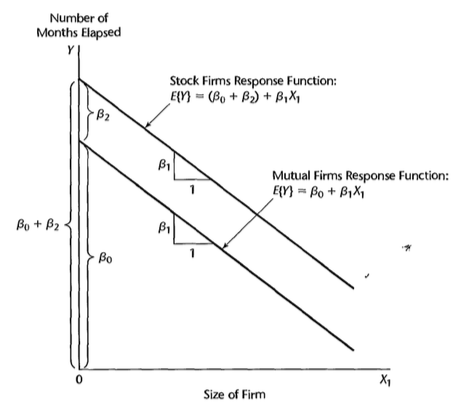

## Exemplo: Seguros

```
##               Estimate  Std. Error    t value     Pr(>|t|)
## (Intercept) 33.8740690 1.813858297  18.675146 9.145269e-13
## X1          -0.1017421 0.008891218 -11.442990 2.074687e-09
## X2           8.0554692 1.459105700   5.520826 3.741874e-05
```

## Exemplo: Seguros

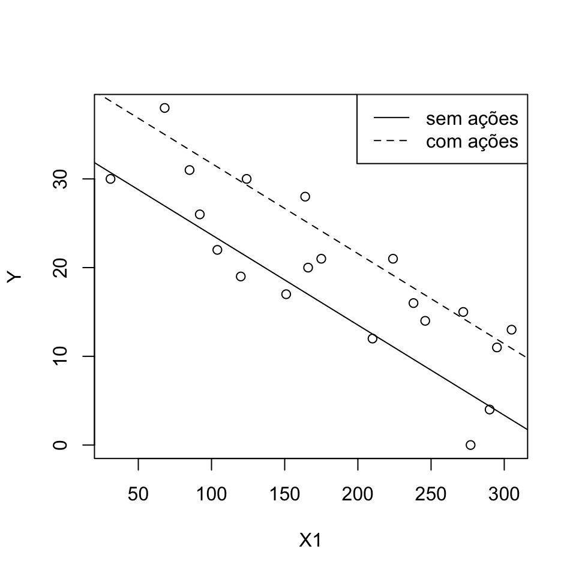

## Exemplo: Seguros

Incluindo termo de interação:

\[Y=\beta_0+\beta_1X_1+\beta_2X_2+\beta_3X_1X_2+\varepsilon\]

\[E(Y)=\beta_0+\beta_1X_1+\beta_2X_2+\beta_3X_1X_2\]

Se a firma não tem ações na bolsa, então \(X_2=0\):

\[E(Y)=\beta_0+\beta_1X_1\]

Se a firma tem ações na bolsa, então \(X_2=1\):

\[E(Y)=(\beta_0+\beta_2)+(\beta_1+\beta_3)X_1\]

## Exemplo: Seguros

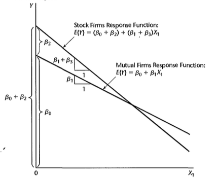

## Exemplo: Seguros

```
##                  Estimate Std. Error     t value     Pr(>|t|)
## (Intercept) 33.8383694765 2.44064985 13.86449166 2.472768e-10
## X1          -0.1015306249 0.01305254 -7.77861250 7.965637e-07
## X2           8.1312501223 3.65405169  2.22526959 4.079375e-02
## I(X1 * X2)  -0.0004171412 0.01833121 -0.02275578 9.821265e-01
```

## Exemplo: Seguros

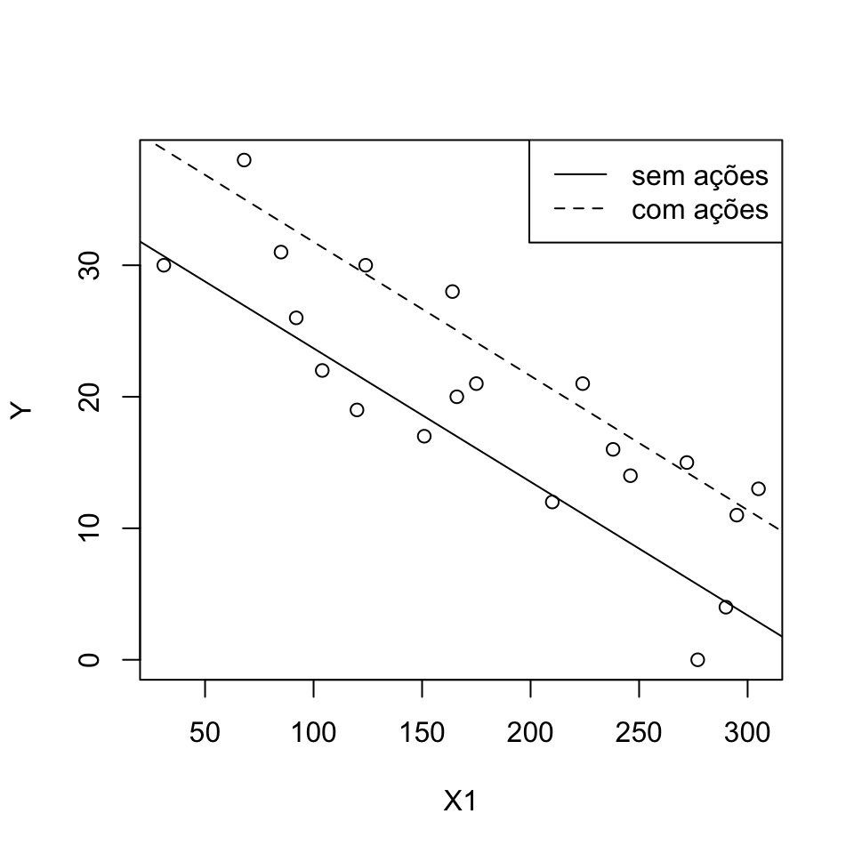